# WHITE WINE ANALYSIS by Jose Maria G.M

We will analyze the variables of the white wine dataset, the variables, their relationships and try to determine what determines a high quality white wine.

# Univariate Plots Section

We are going to perform some preliminary exploration of the dataset. Let’s determine what are the fields of the dataset.

```
##  [1] "X"                    "fixed.acidity"        "volatile.acidity"
##  [4] "citric.acid"          "residual.sugar"       "chlorides"
##  [7] "free.sulfur.dioxide"  "total.sulfur.dioxide" "density"
## [10] "pH"                   "sulphates"            "alcohol"
## [13] "quality"
```

Which are the number of observations and the kind of variables.

```
## 'data.frame':    4898 obs. of  13 variables:
##  $ X                   : int  1 2 3 4 5 6 7 8 9 10 ...
##  $ fixed.acidity       : num  7 6.3 8.1 7.2 7.2 8.1 6.2 7 6.3 8.1 ...
##  $ volatile.acidity    : num  0.27 0.3 0.28 0.23 0.23 0.28 0.32 0.27 0.3 0.22 ...
##  $ citric.acid         : num  0.36 0.34 0.4 0.32 0.32 0.4 0.16 0.36 0.34 0.43 ...
##  $ residual.sugar      : num  20.7 1.6 6.9 8.5 8.5 6.9 7 20.7 1.6 1.5 ...
##  $ chlorides           : num  0.045 0.049 0.05 0.058 0.058 0.05 0.045 0.045 0.049 0.044 ...
##  $ free.sulfur.dioxide : num  45 14 30 47 47 30 30 45 14 28 ...
##  $ total.sulfur.dioxide: num  170 132 97 186 186 97 136 170 132 129 ...
##  $ density             : num  1.001 0.994 0.995 0.996 0.996 ...
##  $ pH                  : num  3 3.3 3.26 3.19 3.19 3.26 3.18 3 3.3 3.22 ...
##  $ sulphates           : num  0.45 0.49 0.44 0.4 0.4 0.44 0.47 0.45 0.49 0.45 ...
##  $ alcohol             : num  8.8 9.5 10.1 9.9 9.9 10.1 9.6 8.8 9.5 11 ...
##  $ quality             : int  6 6 6 6 6 6 6 6 6 6 ...
```

Summary of each variable.

```
##        X        fixed.acidity    volatile.acidity  citric.acid
##  Min.   :   1   Min.   : 3.800   Min.   :0.0800   Min.   :0.0000
##  1st Qu.:1225   1st Qu.: 6.300   1st Qu.:0.2100   1st Qu.:0.2700
##  Median :2450   Median : 6.800   Median :0.2600   Median :0.3200
##  Mean   :2450   Mean   : 6.855   Mean   :0.2782   Mean   :0.3342
##  3rd Qu.:3674   3rd Qu.: 7.300   3rd Qu.:0.3200   3rd Qu.:0.3900
##  Max.   :4898   Max.   :14.200   Max.   :1.1000   Max.   :1.6600
##  residual.sugar     chlorides       free.sulfur.dioxide total.sulfur.dioxide
##  Min.   : 0.600   Min.   :0.00900   Min.   :  2.00      Min.   :  9.0
##  1st Qu.: 1.700   1st Qu.:0.03600   1st Qu.: 23.00      1st Qu.:108.0
##  Median : 5.200   Median :0.04300   Median : 34.00      Median :134.0
##  Mean   : 6.391   Mean   :0.04577   Mean   : 35.31      Mean   :138.4
##  3rd Qu.: 9.900   3rd Qu.:0.05000   3rd Qu.: 46.00      3rd Qu.:167.0
##  Max.   :65.800   Max.   :0.34600   Max.   :289.00      Max.   :440.0
##     density             pH          sulphates         alcohol
##  Min.   :0.9871   Min.   :2.720   Min.   :0.2200   Min.   : 8.00
##  1st Qu.:0.9917   1st Qu.:3.090   1st Qu.:0.4100   1st Qu.: 9.50
##  Median :0.9937   Median :3.180   Median :0.4700   Median :10.40
##  Mean   :0.9940   Mean   :3.188   Mean   :0.4898   Mean   :10.51
##  3rd Qu.:0.9961   3rd Qu.:3.280   3rd Qu.:0.5500   3rd Qu.:11.40
##  Max.   :1.0390   Max.   :3.820   Max.   :1.0800   Max.   :14.20
##     quality
##  Min.   :3.000
##  1st Qu.:5.000
##  Median :6.000
##  Mean   :5.878
##  3rd Qu.:6.000
##  Max.   :9.000
```

We can see that in the sample there are more wine of quality between 5 and 7. It would nice a dataset with more observations about quality 9, we only have 5 observations.

```
##
##    3    4    5    6    7    8    9
##   20  163 1457 2198  880  175    5
```

# Univariate Analysis

Now we are going to plot the histogram of the variables of the dataset white wine.

Plot citric acid:  
It has normal distribution skewed to the right with some outliers.

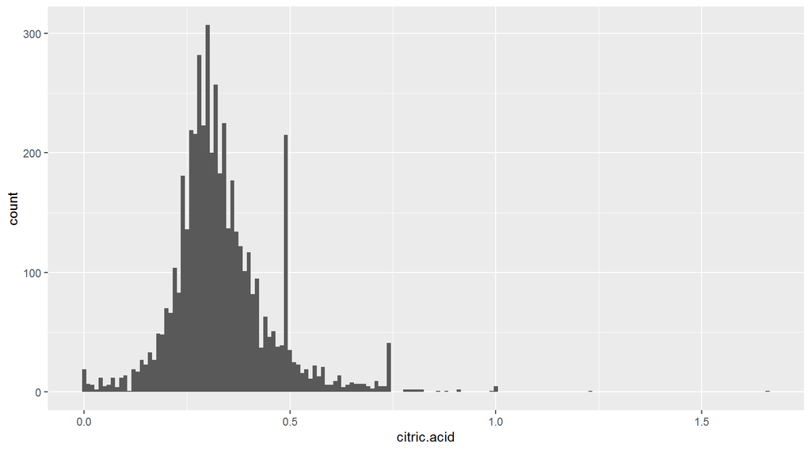

Plot residual sugar:  
The distribution has very high values for low values of residual sugar.

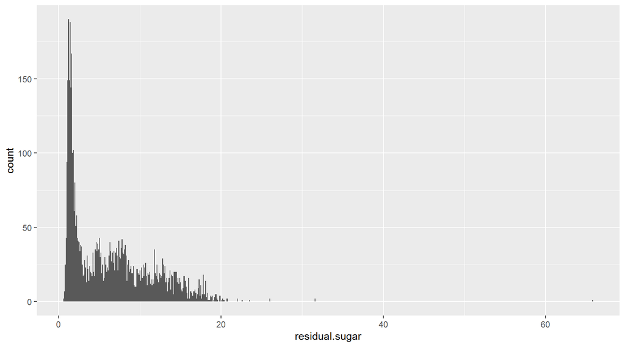

Plot chlorides:  
It has a normal distribution with a hight number of outliers.

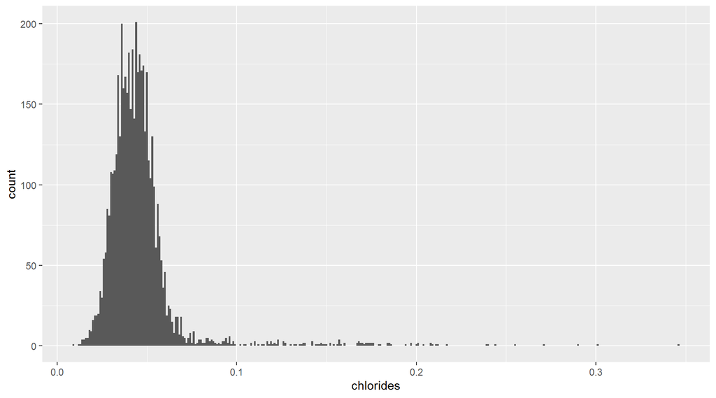

Plot Free Sulfur Dioxides:  
It has a normal distribution skewed to the right.

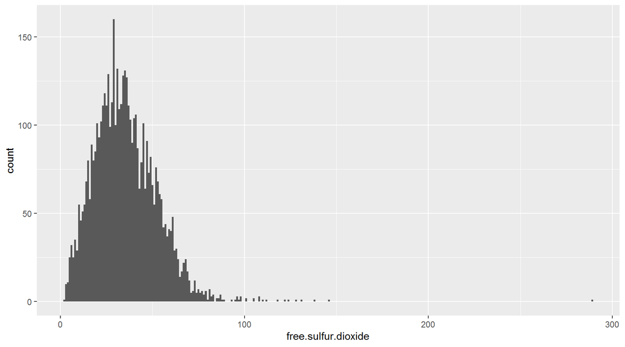

Plot Total Sulfur Dioxides:  
It has a normal distribution with some outliers.

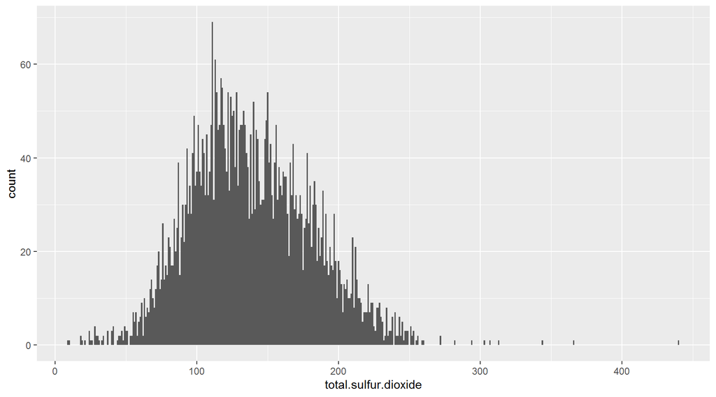

Plot Density:  
It has a normal distribution with values between 0.99 and 1.0. with some outliers.

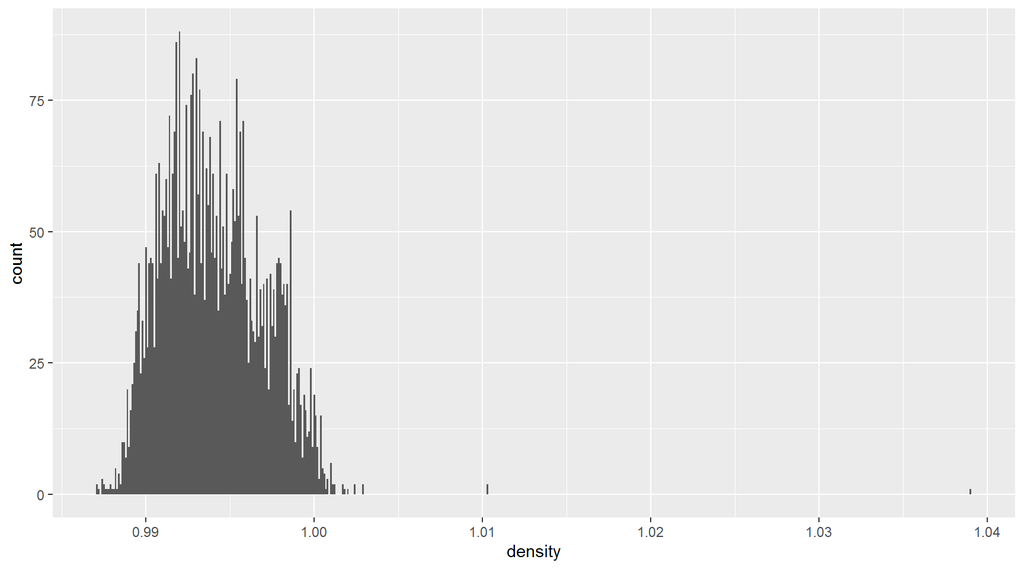

Plot pH:  
It has a normal distribution with a mean of 3.188, it is acid and this gives a refreshing sensation.

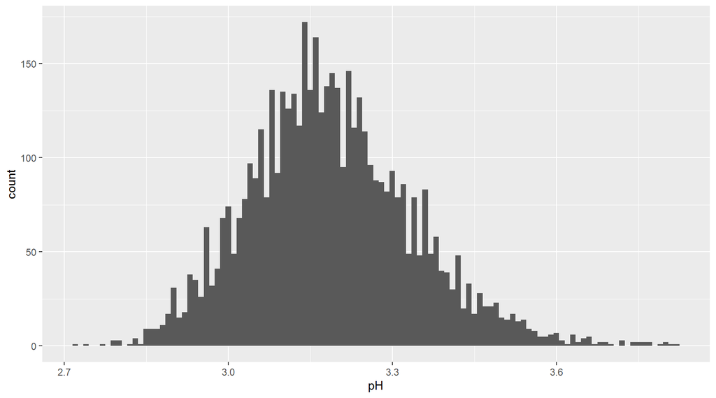

Plot Sulphates:  
It has a normal distribution skewed to the right.

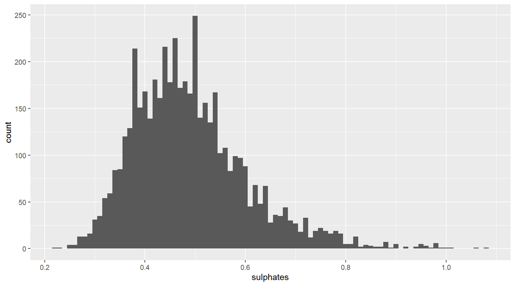

Plot Alcohol:  
It has not a normal distribution with values between 8 and 14.

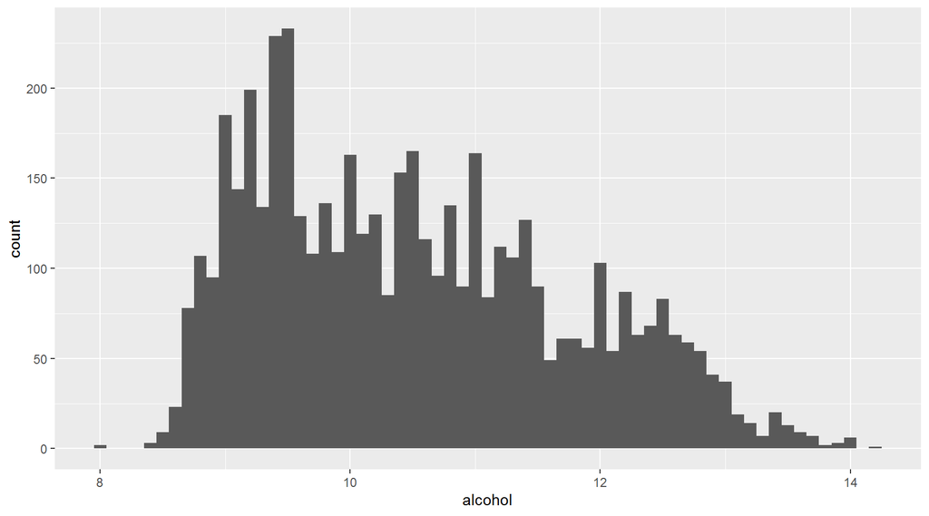

Plot Quality:  
It has a normal distribution.

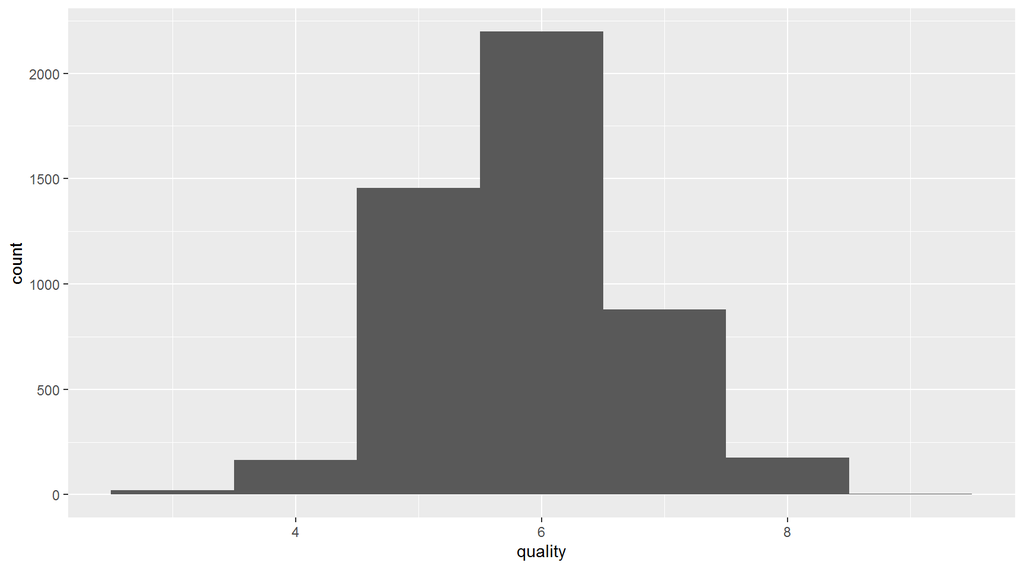

Plot Volatile Acidity:  
It has a normal distribution skewed to the right.

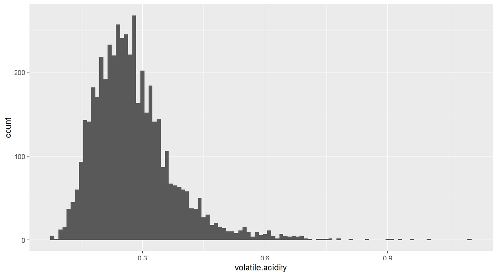

Plot Fix Acidity:  
It has a normal distribution.

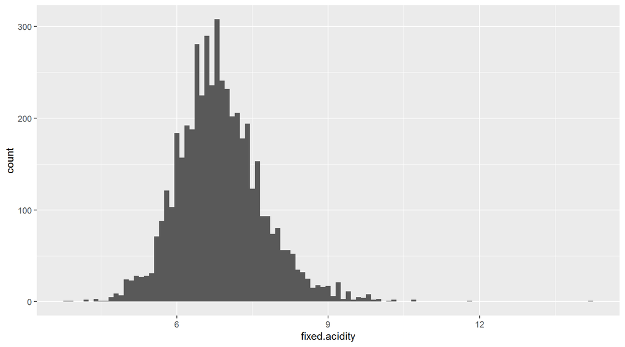

# Bivariate Plots Section

We are going to create a matrix where we can see if there is some correlation between variables.

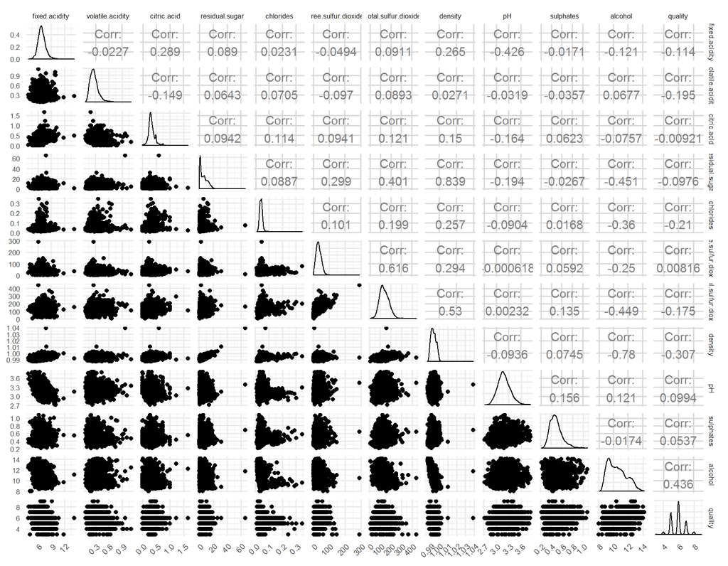

Here we see that there are some variables with a high correlation:  
- density and alcohol -0.78 - free.sulfur.dioxide and total.sulfur.dioxide 0.616 - residual.sugar and density 0.839 - quality and alcohol 0.436 - density - total.sulfur.dioxide 0.53

First examine some relation of variables with low correlation

We see that all white wines in the sample have pH values between 2.72 and 3.82 and the mean value increase for higher quality.

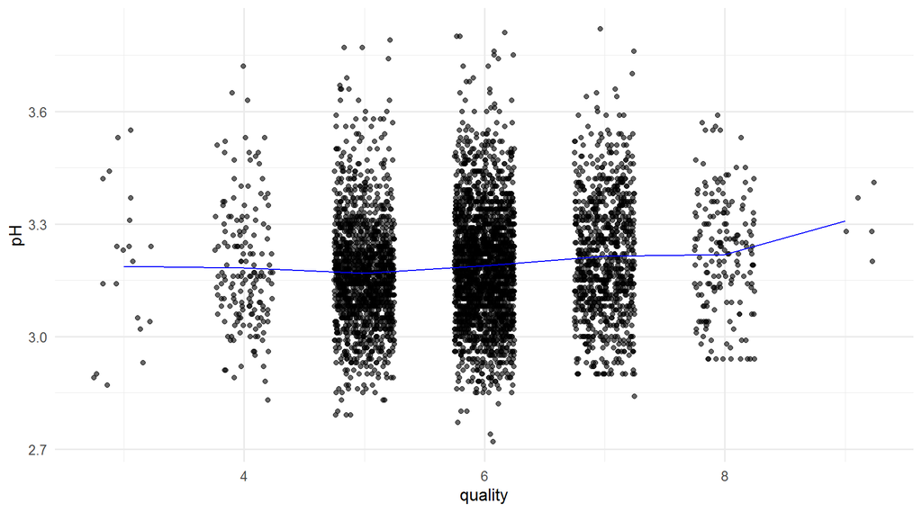

The residual sugar mean does not have a great variations for the quality values.

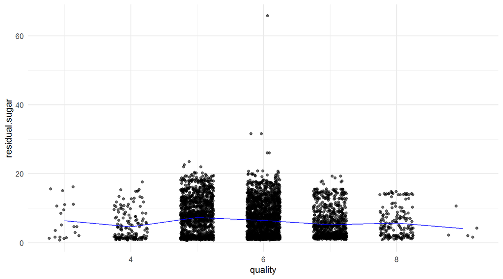

Plot alcohol-quality:  
There is a correlation of 0.436, and we see how the quality increases with alcohol mean.

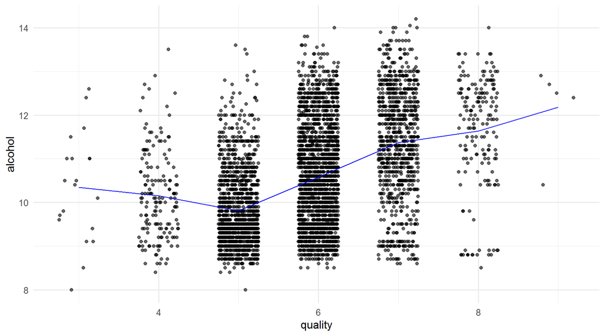

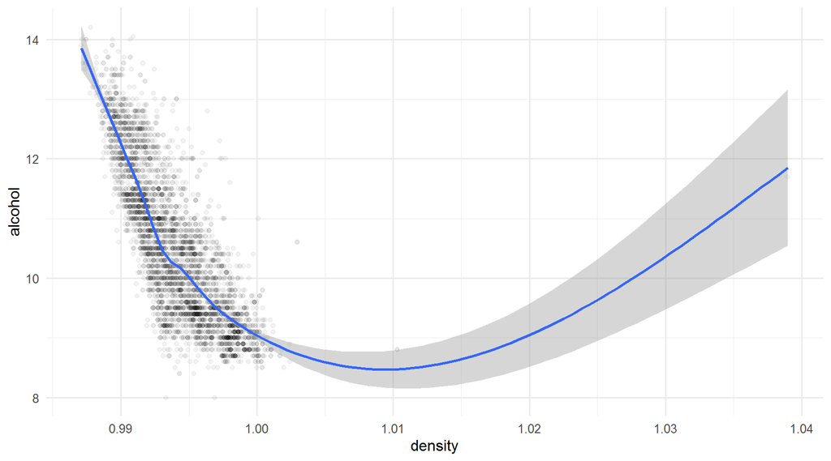

Plot free.sulfur.dioxide - total.sulfur.dioxide:  
There is a correlation 0.616 and there are some outliers. Here when free.sulfur.dioxide increases the total.sulfur.dioxide increases.

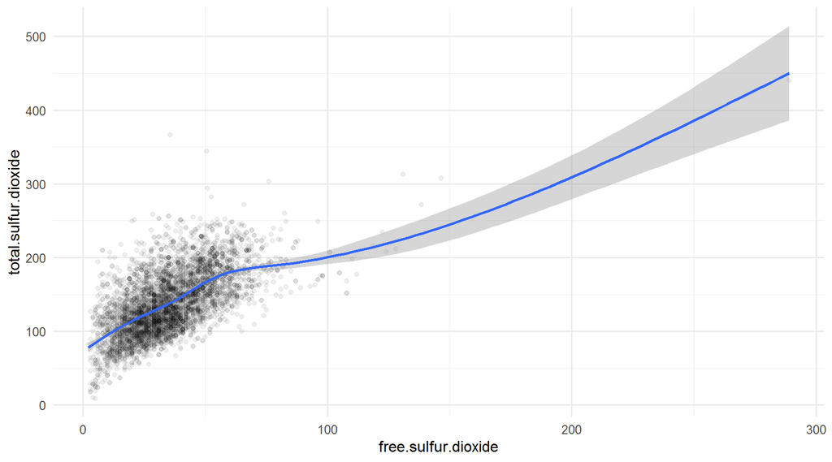

Plot density - total.sulfur.dioxide:  
There is a correlation 0.53 and there are some outliers. Here when density increases the total.sulfur.dioxide increases.

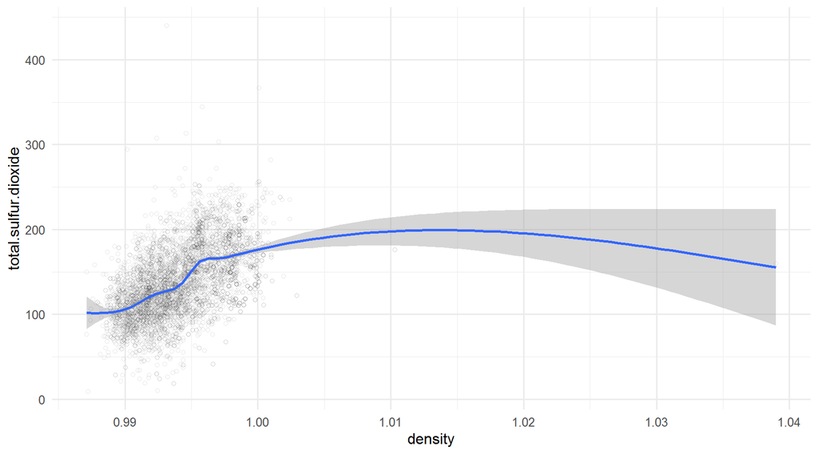

[output not shown]

# Bivariate Analysis

We have seen that there are some strong relation between variables:  
- density and alcohol  
- free.sulfur.dioxide and total.sulfur.dioxide  
- residual.sugar and density  
- quality and alcohol - density and toal sulfur dioxide

Here we have the means of the variables of the dataset of white wine.

Summary means part 1

| quality | alcohol_mean | residual.sugar_mean | density_mean | pH_mean | fixed.acidity_mean | volatile.acidity_mean | n |
| --- | --- | --- | --- | --- | --- | --- | --- |
| 3 | 10.34500 | 6.392500 | 0.9948840 | 3.187500 | 7.600000 | 0.3332500 | 20 |
| 4 | 10.15245 | 4.628221 | 0.9942767 | 3.182883 | 7.129448 | 0.3812270 | 163 |
| 5 | 9.80884 | 7.334969 | 0.9952626 | 3.168833 | 6.933974 | 0.3020110 | 1457 |
| 6 | 10.57537 | 6.441606 | 0.9939613 | 3.188599 | 6.837671 | 0.2605641 | 2198 |
| 7 | 11.36794 | 5.186477 | 0.9924524 | 3.213898 | 6.734716 | 0.2627670 | 880 |
| 8 | 11.63600 | 5.671429 | 0.9922359 | 3.218686 | 6.657143 | 0.2774000 | 175 |
| 9 | 12.18000 | 4.120000 | 0.9914600 | 3.308000 | 7.420000 | 0.2980000 | 5 |

Summary means part 2

| quality | citric.acid_mean | sulphates_mean | chlorides_mean | free.sulfur.dioxide_mean | total.sulfur.dioxide_mean | n |
| --- | --- | --- | --- | --- | --- | --- |
| 3 | 0.3360000 | 0.4745000 | 0.0543000 | 53.32500 | 170.6000 | 20 |
| 4 | 0.3042331 | 0.4761350 | 0.0500982 | 23.35890 | 125.2791 | 163 |
| 5 | 0.3376527 | 0.4822032 | 0.0515463 | 36.43205 | 150.9046 | 1457 |
| 6 | 0.3380255 | 0.4911056 | 0.0452175 | 35.65059 | 137.0473 | 2198 |
| 7 | 0.3256250 | 0.5031023 | 0.0381909 | 34.12557 | 125.1148 | 880 |
| 8 | 0.3265143 | 0.4862286 | 0.0383143 | 36.72000 | 126.1657 | 175 |
| 9 | 0.3860000 | 0.4660000 | 0.0274000 | 33.40000 | 116.0000 | 5 |

# Multivariate Plots Section

Plot residual sugar and density: here we see how increases density when increases residual sugar.

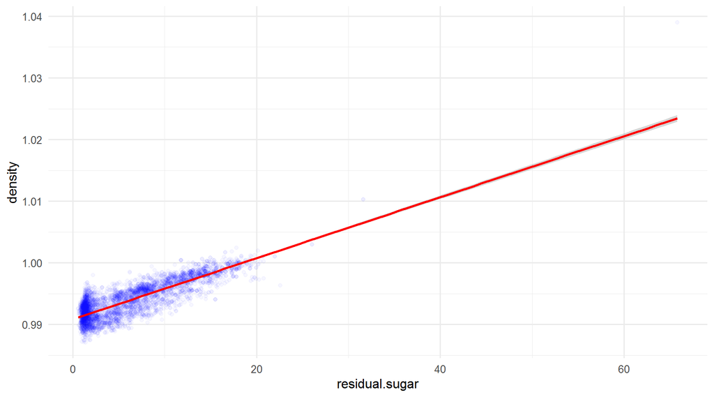

Plot density and chlorides: here we see how decreases chlorides and density increases quality.

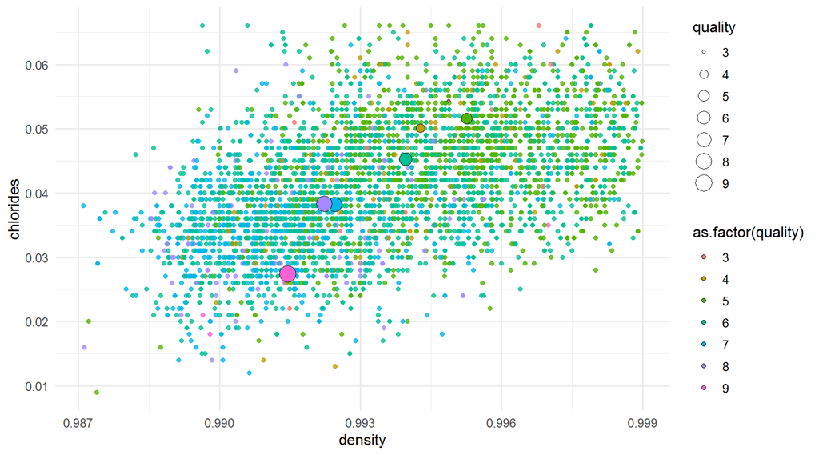

Plot free.sulfur.dioxide and total.sulfur.dioxide: we can see if free.sulfur.dioxide increases also increases total.sulfur.dioxide.

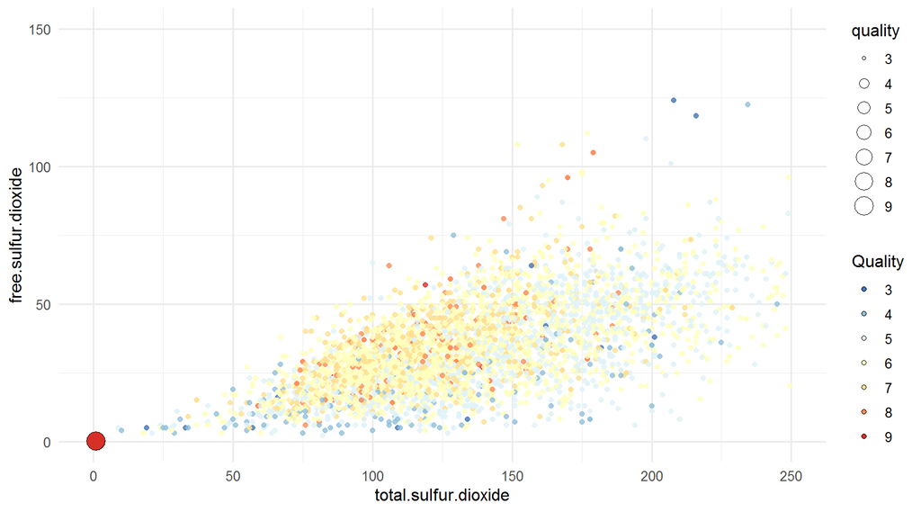

Plot density and alcohol: we can see if alcohol increases also decreases density and increases quality.

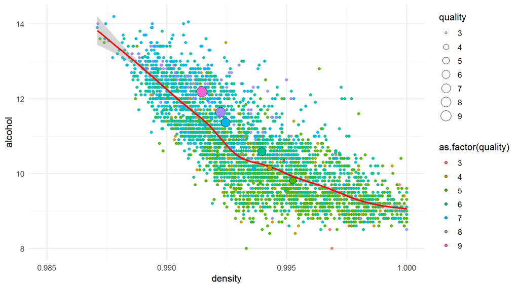

# Multivariate Analysis

We have seen how with high alcohol, low density we have a high quality wine.  
Also chlorides and density decreases, quality increases.

# Final Plots and Summary

### Plot One

[figure not shown]

### Description One

In the previous plot we see density and residual sugar with a correlation of 0.839 is the greater value in the whole variables. It can use a linea regression to estimate the values. If residual sugar decrease density and increases the quality of the white wine.

### Plot Two

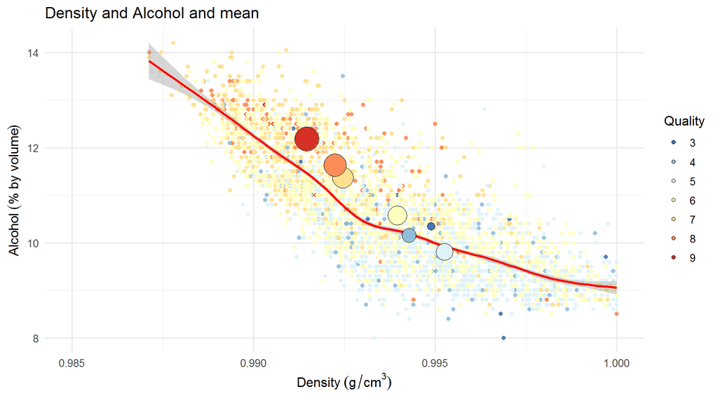

### Description Two

In the previous plot we see the high correlation 0.78 between alcohol and density.When density decreases then alcohol increases and the quality of the wine.

### Plot Three

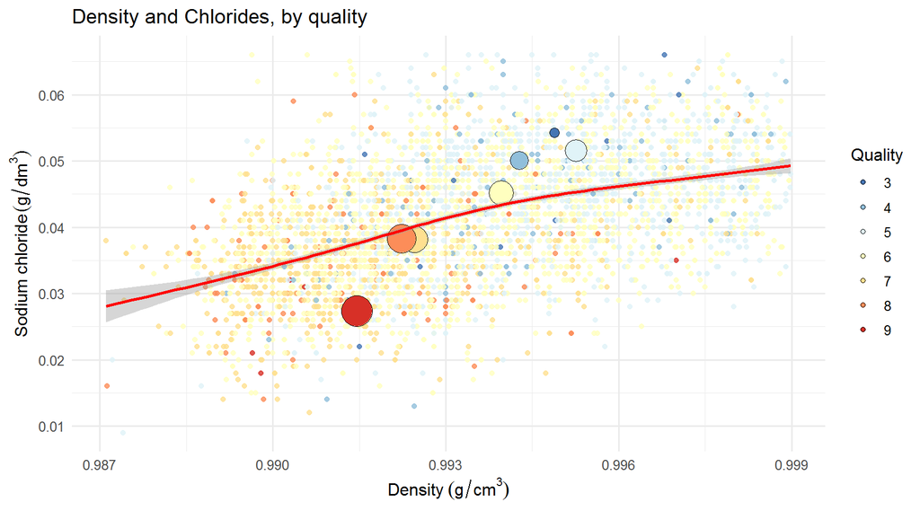

### Description Three

In this plot we see how with low density and low chlorides we have high quality white wines.

# Reflection

We have some variables with high correlations:  
- density and alcohol  
- free.sulfur.dioxide and total.sulfur.dioxide  
- residual.sugar and density  
- quality and alcohol

Also we have discovered that we high alcohol and low density we have high quality white wines. And with low chlorides and low density we have high quality white wines.

Here we have a few variables and I only have checked linear correlation, which would be the methology for a high number of variables? how could I detect other kind of relation between two or more variables?

In relation to R I have had some problems to search a way to show the tables of means variables.

With these infomation now we could predict the quality of a white wine.